# PA1_template.Rmd

Roshan

December 30, 2018

```r
#setwd("./Project")
library(data.table)
library(dplyr)
library(tidyverse)
library(ggplot2)
library(lubridate)
```

```r
#read data from the csv file
originalData = read.csv("activity.csv")

#change the date as Date class and format "%m-%d-%Y"
originalData$date <- as.Date(originalData$date,format = "%m/%d/%Y")
originalData$date <- format.Date(originalData$date,"%m-%d-%Y")

#remove NA rows from the data
originalData<-originalData[!is.na(originalData$steps),]
```

### [1] What is mean total number of steps taken per day?

```r
#read the original data from csv file
 originalData = read.csv("activity.csv")

#change the date as Date class and format "%m-%d-%Y"
 originalData$date <- as.Date(originalData$date,format = "%m/%d/%Y")
originalData$date <- format.Date(originalData$date,"%m-%d-%Y")

#select only !NA values
originalData<-originalData[!is.na(originalData$steps),]

#keep seperate calculation for for with NA
originalDataNA = read.csv("activity.csv")

# calculate sum of steps per date
data <- originalData %>%
        group_by(date) %>%
        summarise(totalSteps = sum(steps))%>%
        ungroup()
#construct the plot
g <- ggplot(data, aes(data$totalSteps)) +
  geom_histogram(breaks=seq(10, 22000, by=1000),col="grey",fill= "red") +
   ggtitle("Total Steps Counts per Date") +
  theme(plot.title = element_text(hjust = 0.5)) +
  xlab("Interval") +
  ylab("Total Step Counts")

#calculate the mean and mean of total steps
TotStepsMedian <- as.integer(median(data$totalSteps))
TotStepsMean <- as.integer(mean(data$totalSteps))
```

#### histogram of the total number of steps taken each day

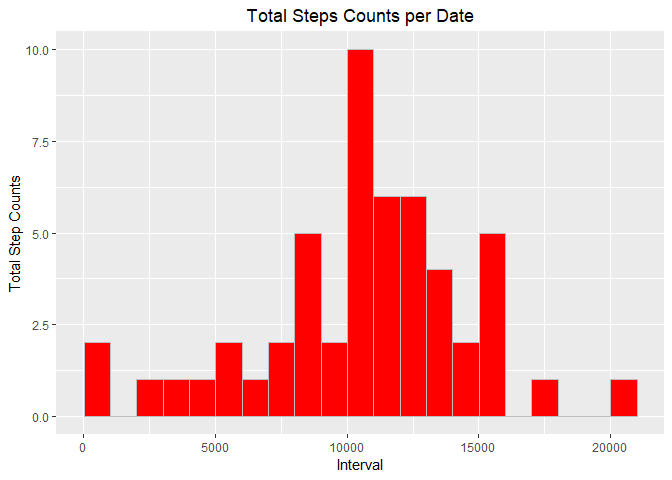

Mean total-number of steps taken per day: **10765**

Median total number of steps taken per day: **10766**

### [2] What is the average daily activity pattern?

```r
#calculate average of steps
aveDailyActivity <- originalData %>%
                    group_by(interval) %>%
                    summarise(aveSteps = mean(steps))

#calculate maximum of average steps
maxX <- max(aveDailyActivity$aveSteps)

#calcuate average daily activities with maximum aveSteps
maxY <- aveDailyActivity[aveDailyActivity$aveSteps==maxX,]

#set label
labels  = paste("[", paste(as.numeric(maxY[1,1]),
#set all maxY as numeric
ceiling(as.numeric(maxY[1,2])),sep=","),"]")

#plot interval vs aveSteps
g2 <- ggplot(aveDailyActivity, aes(aveDailyActivity$interval,aveDailyActivity$aveSteps )) + geom_line() +
  ggtitle("Average Steps Over 5min Intervals") +
  theme(plot.title = element_text(hjust = 0.5)) +
  xlab("Time Interval (5min unites)") + ylab("Average Steps") +
  geom_text(aes(as.numeric(maxY[1,1] + 300), as.numeric(maxY[1,2])),label= labels)
```

#### The average daily activity pattern

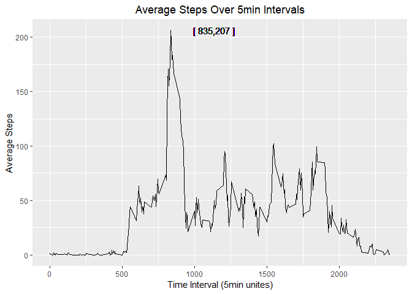

#### Maximum number of steps - on average across all the days

Which 5-minute interval, on average across all the days in the dataset, contains the maximum number of steps? **835**

### [3]Imputing missing values

#### Calculate and report the total number of missing values in the dataset

```r
#count total NA value rows in original data with NA
countsNA = count(originalDataNA,is.na(originalDataNA$step))

#set count numbers as numeric
totalNA <- as.numeric(countsNA[2,2])
```

The total number of rows with NAs is **2304**

#### Devise a strategy for filling in all of the missing values in the dataset

```r
#read dataset again to make sure itis original
originalData = read.csv("activity.csv")

#change the date as Date class and format "%m-%d-%Y"
originalData$date <- as.Date(originalData$date,format = "%m/%d/%Y")
originalData$date <- format.Date(originalData$date,"%m-%d-%Y")

#original Data without NAs
originalDataWithoutNA<-originalData[!is.na(originalData$steps),]

#read data to use with NAs
dataWithNA = read.csv("activity.csv")

#change the date as Date class and format "%m-%d-%Y"
dataWithNA$date <- as.Date(dataWithNA$date,format = "%m/%d/%Y")
dataWithNA$date <- format.Date(dataWithNA$date,"%m-%d-%Y")

#calculate the average steps without NAs over interval
aveDailyActivityWtNA <- originalDataWithoutNA %>%
                      dplyr::group_by(interval) %>%
                      dplyr::summarise(aveSteps = mean(steps))

aveDailyActivityWtNA$aveSteps <- ceiling(aveDailyActivityWtNA$aveSteps )

#sum over new aveDailyActivityWtNA set aveSteps
dataNA<- aveDailyActivityWtNA %>%
    dplyr::summarise(totalSteps = sum(aveSteps))

dataNA$totalSteps <- ceiling(dataNA$totalSteps)

#calculate sum over all original data with NA
 data <- dataWithNA %>%
   group_by(date) %>%
   summarise(totalSteps = sum(steps))%>%
   ungroup()

 #mutate dataset that is equal to the original dataset but with the missing data
 data <- data %>% mutate(totalSteps = ifelse(is.na(totalSteps), dataNA, totalSteps))

 #set totalSteps as integer to match origina type -- NEW Data
 data$totalSteps <- as.integer(data$totalSteps)

  #construct the plot
g3 <- ggplot(data, aes(data$totalSteps)) +
      geom_histogram(breaks=seq(10, 22000, by=1000),col="grey",fill= "red") +
      labs(title = "                      Total Steps Counts per Date") +
      xlab("Total Steps") +
      ylab("Total Step Counts")
```

#### Histogram of the total number of steps taken each day with NA replaced

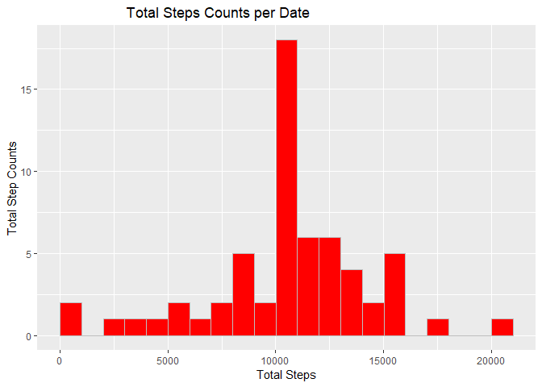

#### Mean and Median total number of steps taken per day with replaced NAs

Mean total-number of steps taken per day with replaced NAs: **10909**

Median total number of steps taken per day with replaced NAs: **10784**

#### Difference in Mean and Median total number of steps taken per day w/out replaced NAs

Mean difference = **144**

Median difference = **18**

Percentage of mean diffrence = **1.3376684**

Percentage of median diffrence = **0.167193**

! Replacing NAs with averaged sum over interals wont impact significatly on data

### Are there differences in activity patterns between weekdays and weekends?

#### Plot of average number of steps taken, averaged across all weekday days or weekend days

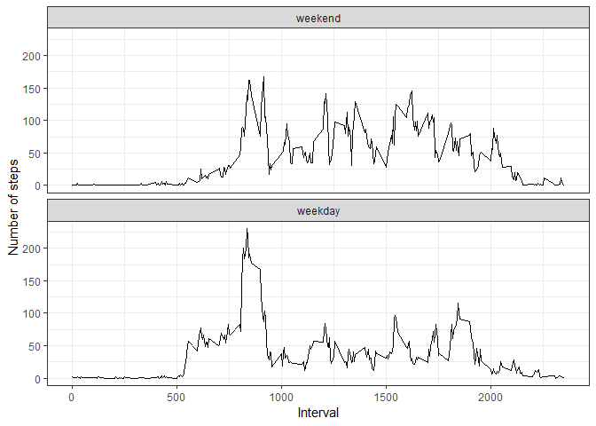